# 11b_boosting

### AdaBoost [Classification](https://scikit-learn.org/stable/modules/generated/sklearn.ensemble.AdaBoostClassifier.html#sklearn.ensemble.AdaBoostClassifier) & [Regression](https://scikit-learn.org/stable/modules/generated/sklearn.ensemble.AdaBoostRegressor.html#sklearn.ensemble.AdaBoostRegressor)

- Fits a *sequence of weak learners* on repeatedly modified versions of a dataset.
- Combines the predictions via a *weighted majority voting* system.
- Uses a *weights vector* ($w_1, w_2, w_N$) to boost each training sample - each weight is initialized to 1/N
- Incorrectly predicted samples have their weights *increased* for subsequent runs.
- Correctly predicted samples have their weights *decreased* for subsequent runs.
- Therefore, subsequent learners are forced to concentrate on examples that were previously missed.

```python
from sklearn.model_selection import cross_val_score
from sklearn.datasets import load_iris
from sklearn.ensemble import AdaBoostClassifier

X, y   = load_iris(return_X_y=True)
clf    = AdaBoostClassifier(n_estimators=100) # AdaBoost on 100 weak classifiers
scores = cross_val_score(clf, X, y, cv=5)
scores.mean()
```

```
0.9466666666666665
```

- `n_estimators` controls the numbers of learners.
- `learning_rate` controls the contribution of weak learners in the final combination.
- Weak learners are, in effect, decision stumps.
- `base_estimator` controls the estimator method.

### Example: Discrete (SAMME) vs Real (SAMME.R) AdaBoost comparison

- Binary classification task
- Y is nonlinear function with 10 inputs.

```python
import numpy as np
import matplotlib.pyplot as plt
from sklearn import datasets
from sklearn.tree import DecisionTreeClassifier as DTC
from sklearn.metrics import zero_one_loss
from sklearn.ensemble import AdaBoostClassifier as ABC
```

```python
n, lr = 400, 1.0

X, y             = datasets.make_hastie_10_2(n_samples=12000, random_state=1)
X_test, y_test   = X[2000:], y[2000:]
X_train, y_train = X[:2000], y[:2000]

dt_stump = DTC(max_depth=1, min_samples_leaf=1)
dt       = DTC(max_depth=9, min_samples_leaf=1)

dt.fit(      X_train, y_train)
dt_stump.fit(X_train, y_train)

dt_err       = 1.0 - dt.score(      X_test, y_test)
dt_stump_err = 1.0 - dt_stump.score(X_test, y_test)

ada_discrete = ABC(base_estimator=dt_stump, learning_rate=lr, n_estimators=n, algorithm="SAMME")
ada_real     = ABC(base_estimator=dt_stump, learning_rate=lr, n_estimators=n, algorithm="SAMME.R")

ada_discrete.fit(X_train, y_train)
ada_real.fit(X_train, y_train)
```

```
AdaBoostClassifier(base_estimator=DecisionTreeClassifier(max_depth=1),
                   n_estimators=400)
```

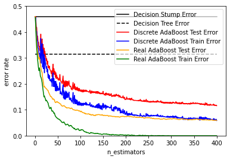

```python
fig = plt.figure()
ax = fig.add_subplot(111)

ax.plot([1, n], [dt_stump_err] * 2, 'k-',
        label='Decision Stump Error')
ax.plot([1, n], [dt_err] * 2, 'k--',
        label='Decision Tree Error')

ada_discrete_err = np.zeros(      (n,))
ada_discrete_err_train = np.zeros((n,))
ada_real_err = np.zeros(          (n,))
ada_real_err_train = np.zeros(    (n,))

for i, y_pred in enumerate(ada_discrete.staged_predict(X_test)):
    ada_discrete_err[i] = zero_one_loss(y_pred, y_test)

for i, y_pred in enumerate(ada_discrete.staged_predict(X_train)):
    ada_discrete_err_train[i] = zero_one_loss(y_pred, y_train)

for i, y_pred in enumerate(ada_real.staged_predict(X_test)):
    ada_real_err[i] = zero_one_loss(y_pred, y_test)

for i, y_pred in enumerate(ada_real.staged_predict(X_train)):
    ada_real_err_train[i] = zero_one_loss(y_pred, y_train)

ax.plot(np.arange(n) + 1, ada_discrete_err,
        label='Discrete AdaBoost Test Error',
        color='red')
ax.plot(np.arange(n) + 1, ada_discrete_err_train,
        label='Discrete AdaBoost Train Error',
        color='blue')
ax.plot(np.arange(n) + 1, ada_real_err,
        label='Real AdaBoost Test Error',
        color='orange')
ax.plot(np.arange(n) + 1, ada_real_err_train,
        label='Real AdaBoost Train Error',
        color='green')

ax.set_ylim((0.0, 0.5))
ax.set_xlabel('n_estimators')
ax.set_ylabel('error rate')

leg = ax.legend(loc='upper right', fancybox=True)
leg.get_frame().set_alpha(0.7)

plt.show()
```

### Example: Multiclass AdaBoost

- Compares accuracy of *SAMME* (classification only) to *SAMME.R* (updates additive model)
- Dataset: 10-dimensional std normal distribution
- 3 classes separated by nested, concentric 10-D spheres
- Roughly equal numbers of samples in each class
- Expectation: SAMME.R should converge faster, with lower test error
- Algorithm error on the left; classification error in the middle; boost weights on the right.

```python
import matplotlib.pyplot as plt

from sklearn.datasets import make_gaussian_quantiles
from sklearn.metrics  import accuracy_score
from sklearn.ensemble import AdaBoostClassifier as ABC
from sklearn.tree     import DecisionTreeClassifier as DTC

X, y = make_gaussian_quantiles(n_samples=13000, n_features=10, n_classes=3, random_state=1)

n_split = 3000

X_train, X_test = X[:n_split], X[n_split:]
y_train, y_test = y[:n_split], y[n_split:]

bdt_real     = ABC(DTC(max_depth=2), n_estimators=600, learning_rate=1)
bdt_discrete = ABC(DTC(max_depth=2), n_estimators=600, learning_rate=1.5, algorithm="SAMME")

bdt_real.fit(    X_train, y_train)
bdt_discrete.fit(X_train, y_train)

real_test_errors, discrete_test_errors = [],[]
```

```python
for real_test_predict, discrete_train_predict in zip(
        bdt_real.staged_predict(X_test),
        bdt_discrete.staged_predict(X_test)):

    real_test_errors.append(    1. - accuracy_score(     real_test_predict, y_test))
    discrete_test_errors.append(1. - accuracy_score(discrete_train_predict, y_test))

n_trees_discrete = len(bdt_discrete)
n_trees_real = len(bdt_real)
```

```python
# Boosting might terminate early, but the arrays are always n_estimators long.
# Crop them to the actual number of trees here:

discrete_estimator_errors  = bdt_discrete.estimator_errors_[:n_trees_discrete]
real_estimator_errors      = bdt_real.estimator_errors_[:n_trees_real]
discrete_estimator_weights = bdt_discrete.estimator_weights_[:n_trees_discrete]
```

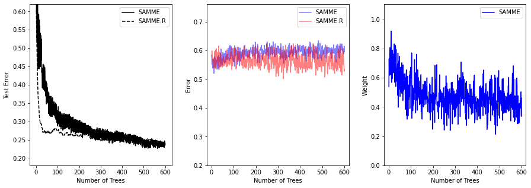

```python
plt.figure(figsize=(15, 5))

plt.subplot(131)
plt.plot(range(1, n_trees_discrete + 1), discrete_test_errors, c='black', label='SAMME')
plt.plot(range(1, n_trees_real + 1),         real_test_errors, c='black', linestyle='dashed', label='SAMME.R')
plt.legend()
plt.ylim(0.18, 0.62)
plt.ylabel('Test Error'); plt.xlabel('Number of Trees')

plt.subplot(132)
plt.plot(range(1, n_trees_discrete + 1), discrete_estimator_errors, "b", label='SAMME', alpha=.5)
plt.plot(range(1, n_trees_real + 1),         real_estimator_errors, "r", label='SAMME.R', alpha=.5)
plt.legend()
plt.ylabel('Error'); plt.xlabel('Number of Trees')
plt.ylim((.2,
         max(real_estimator_errors.max(),
             discrete_estimator_errors.max()) * 1.2))
plt.xlim((-20, len(bdt_discrete) + 20))

plt.subplot(133)
plt.plot(range(1, n_trees_discrete + 1), discrete_estimator_weights, "b", label='SAMME')
plt.legend()
plt.ylabel('Weight')
plt.xlabel('Number of Trees')
plt.ylim((0, discrete_estimator_weights.max() * 1.2))
plt.xlim((-20, n_trees_discrete + 20))

# prevent overlapping y-axis labels
plt.subplots_adjust(wspace=0.25)
plt.show()
```

### Example: AdaBoost, 2-classes

- Plots decision boundaries and decision scores
- Scores>0 are "B", otherwise "A"
- Score magnitude indicates confidence

```python
import numpy as np
import matplotlib.pyplot as plt
from sklearn.ensemble import AdaBoostClassifier as ABC
from sklearn.tree import DecisionTreeClassifier as DTC
from sklearn.datasets import make_gaussian_quantiles

# Construct dataset
X1, y1 = make_gaussian_quantiles(cov=2.,
                                 n_samples=200, n_features=2,
                                 n_classes=2, random_state=1)
X2, y2 = make_gaussian_quantiles(mean=(3, 3), cov=1.5,
                                 n_samples=300, n_features=2,
                                 n_classes=2, random_state=1)
X = np.concatenate((X1, X2))
y = np.concatenate((y1, - y2 + 1))

# Create and fit an AdaBoosted decision tree
bdt = ABC(DTC(max_depth=1), algorithm="SAMME", n_estimators=200)
bdt.fit(X, y)
```

```
AdaBoostClassifier(algorithm='SAMME',
                   base_estimator=DecisionTreeClassifier(max_depth=1),
                   n_estimators=200)
```

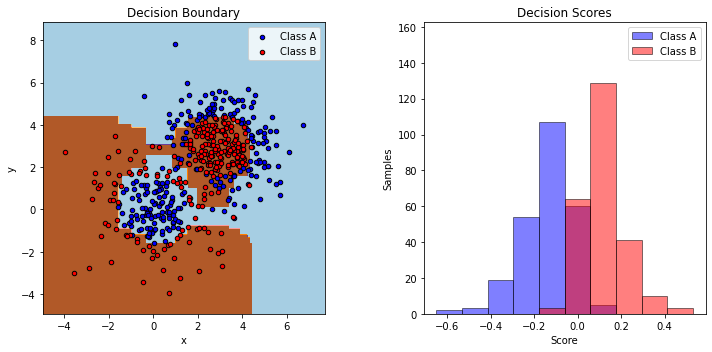

```python
plot_colors, plot_step, class_names = "br", 0.02, "AB"

plt.figure(figsize=(10, 5))

# decision boundaries
plt.subplot(121)
x_min, x_max = X[:, 0].min() - 1, X[:, 0].max() + 1
y_min, y_max = X[:, 1].min() - 1, X[:, 1].max() + 1
xx, yy = np.meshgrid(np.arange(x_min, x_max, plot_step),
                     np.arange(y_min, y_max, plot_step))

Z = bdt.predict(np.c_[xx.ravel(), yy.ravel()])
Z = Z.reshape(xx.shape)
cs = plt.contourf(xx, yy, Z, cmap=plt.cm.Paired)
plt.axis("tight")

# training points
for i, n, c in zip(range(2), class_names, plot_colors):
    idx = np.where(y == i)
    plt.scatter(X[idx, 0], X[idx, 1],
                c=c, cmap=plt.cm.Paired,
                s=20, edgecolor='k',
                label="Class %s" % n)

plt.xlim(x_min, x_max)
plt.ylim(y_min, y_max)
plt.legend(loc='upper right')
plt.xlabel('x'); plt.ylabel('y'); plt.title('Decision Boundary')

# two-class decision scores
twoclass_output = bdt.decision_function(X)
plot_range = (twoclass_output.min(), twoclass_output.max())
plt.subplot(122)
for i, n, c in zip(range(2), class_names, plot_colors):
    plt.hist(twoclass_output[y == i],
             bins=10,
             range=plot_range,
             facecolor=c,
             label='Class %s' % n,
             alpha=.5,
             edgecolor='k')

x1, x2, y1, y2 = plt.axis()
plt.axis((x1, x2, y1, y2 * 1.2))
plt.legend(loc='upper right')
plt.ylabel('Samples'); plt.xlabel('Score'); plt.title('Decision Scores')

plt.tight_layout()
plt.subplots_adjust(wspace=0.35)
plt.show()
```

### Example: Decision Tree Regression with AdaBoost

- 1D sinusoidal data with Gaussian noise

```python
import numpy as np
import matplotlib.pyplot as plt
from sklearn.tree import DecisionTreeRegressor as DTR
from sklearn.ensemble import AdaBoostRegressor as ABR
```

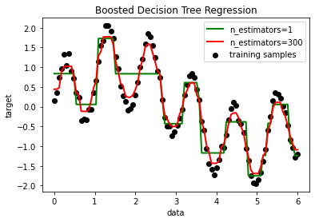

```python
rng = np.random.RandomState(1)
X = np.linspace(0, 6, 100)[:, np.newaxis]
y = np.sin(X).ravel() + np.sin(6 * X).ravel() + rng.normal(0, 0.1, X.shape[0])

# Fit regression model
regr_1 =     DTR(max_depth=4)
regr_2 = ABR(DTR(max_depth=4), n_estimators=300, random_state=rng)

regr_1.fit(X,y); regr_2.fit(X,y)

# Predict
y_1 = regr_1.predict(X)
y_2 = regr_2.predict(X)

# Plot the results
plt.figure()
plt.scatter(X, y, c="k", label="training samples")
plt.plot(X, y_1, c="g", label="n_estimators=1", linewidth=2)
plt.plot(X, y_2, c="r", label="n_estimators=300", linewidth=2)
plt.xlabel("data")
plt.ylabel("target")
plt.title("Boosted Decision Tree Regression")
plt.legend()
plt.show()
```

### [Gradient Boosted Decision Trees](https://en.wikipedia.org/wiki/Gradient_boosting)

- Boosting mechanism using arbitrary differentiable loss functions
- Scikit-Learn implementations inspired by LightGBM
- New histogram-based [classifier](https://scikit-learn.org/stable/modules/generated/sklearn.ensemble.HistGradientBoostingClassifier.html#sklearn.ensemble.HistGradientBoostingClassifier) & [regressor](https://scikit-learn.org/stable/modules/generated/sklearn.ensemble.HistGradientBoostingRegressor.html#sklearn.ensemble.HistGradientBoostingRegressor) are much faster than the std Gradient Boosting [classifier](https://scikit-learn.org/stable/modules/generated/sklearn.ensemble.GradientBoostingClassifier.html#sklearn.ensemble.GradientBoostingClassifier) & [regressor](https://scikit-learn.org/stable/modules/generated/sklearn.ensemble.GradientBoostingRegressor.html#sklearn.ensemble.GradientBoostingRegressor) when sample sizes > 10K.

### [Gradient Boosting Classifier](https://scikit-learn.org/stable/modules/generated/sklearn.ensemble.GradientBoostingClassifier.html#sklearn.ensemble.GradientBoostingClassifier)

- Supports binary & multiclass classification
- Number of weak learners (regression trees) is controlled with `n_estimators`. Tree size is controlled with `max_depth` and `max_leaf_nodes`.
- `learning_rate` controls overfitting via *shrinkage*. It is valued as [0.0..1.0].
- Classification with >2 classes requires induction of `n_classes` trees at each iteration. You should use `HistGradientBoostingClassifier` for datasets with large numbers of classes.

```python
from sklearn.datasets import make_hastie_10_2
from sklearn.ensemble import GradientBoostingClassifier

X, y = make_hastie_10_2(random_state=0)
X_train, X_test = X[:2000], X[2000:]
y_train, y_test = y[:2000], y[2000:]

clf = GradientBoostingClassifier(n_estimators=100, learning_rate=1.0,
    max_depth=1, random_state=0).fit(X_train, y_train)
clf.score(X_test, y_test)
```

```
0.913
```

### [Gradient Boosting Regressor](https://scikit-learn.org/stable/modules/generated/sklearn.ensemble.GradientBoostingRegressor.html#sklearn.ensemble.GradientBoostingRegressor)

- Supports different loss functions via `loss`. The default is *least squares* (`ls`).

```python
import numpy as np
from sklearn.metrics import mean_squared_error
from sklearn.datasets import make_friedman1
from sklearn.ensemble import GradientBoostingRegressor as GBR

X, y = make_friedman1(n_samples=1200,
                      random_state=0,
                      noise=1.0)

X_train, X_test = X[:200], X[200:]
y_train, y_test = y[:200], y[200:]

est = GBR(n_estimators=100,
          learning_rate=0.1,
          max_depth=1,
          random_state=0,
          loss='ls').fit(X_train, y_train)

mean_squared_error(y_test, est.predict(X_test))
```

```
5.009154859960321
```

### [Example: Gradient Boosting Regressor](https://scikit-learn.org/stable/auto_examples/ensemble/plot_gradient_boosting_regression.html)

- Applies LS loss & 500 base learners to the diabetes dataset.
- Plots training & test error vs iteration count.

```python
import matplotlib.pyplot as plt
import numpy as np
from sklearn import datasets, ensemble
from sklearn.inspection import permutation_importance
from sklearn.metrics import mean_squared_error
from sklearn.model_selection import train_test_split
```

```python
diabetes = datasets.load_diabetes()
X, y = diabetes.data, diabetes.target

X_train, X_test, y_train, y_test = train_test_split(
    X, y, test_size=0.1, random_state=13)

params = {'n_estimators': 500,
          'max_depth': 4,
          'min_samples_split': 5,
          'learning_rate': 0.01,
          'loss': 'ls'}

reg = ensemble.GradientBoostingRegressor(**params)
reg.fit(X_train, y_train)

mse = mean_squared_error(y_test, reg.predict(X_test))
print("The mean squared error (MSE) on test set: {:.4f}".format(mse))
```

```
The mean squared error (MSE) on test set: 3030.9181
```

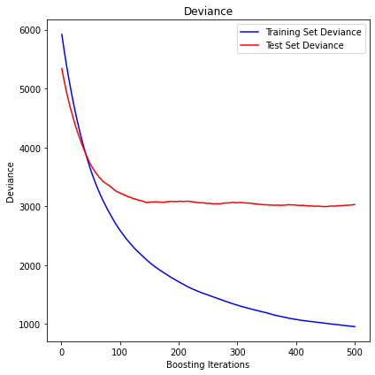

```python
test_score = np.zeros((params['n_estimators'],), dtype=np.float64)
for i, y_pred in enumerate(reg.staged_predict(X_test)):
    test_score[i] = reg.loss_(y_test, y_pred)

fig = plt.figure(figsize=(6, 6))
plt.subplot(1, 1, 1)
plt.title('Deviance')
plt.plot(np.arange(params['n_estimators']) + 1, reg.train_score_, 'b-',
         label='Training Set Deviance')
plt.plot(np.arange(params['n_estimators']) + 1, test_score, 'r-',
         label='Test Set Deviance')
plt.legend(loc='upper right')
plt.xlabel('Boosting Iterations')
plt.ylabel('Deviance')
fig.tight_layout()
```

### Tree Size

- The size of the regression tree base learners defines the level of variable interactions that can be captured by gradient boosting. In general, a tree of depth `h` captures interactions of order `h`.
- `max_depth=h` allows binary trees of depth `h`. They will have (at most) 2^h leaf nodes and 2^h-1 split nodes.
- `max_leaf_nodes` controls the number of leaf nodes. In this case, trees will grow using *best-first search* - nodes with the *highest improvement in impurity* will be expanded first.
- `max_leaf_nodes=k` gives comparable results to `max_depth=k-1` but is *significantly faster to train* vs a *slightly higher training error*.

### Math Foundations

- TODO

### Loss Functions

- Regression:
  - *least squares* (`ls`): the default choice. Initial model given by the *mean of the target values*.
  - *least absolute deviation* (`lad`): Initial model given by the *median of the target values*.
  - *huber* (`huber`): Combines LS & LAD; uses `alpha` to control outlier sensitivity.
  - *quantile* (`quantile`): For quantile regression, aka prediction intervals. Uses `0<alpha<1` to specify the quantile.
- Classification:
  - *binomial deviance* (`deviance`): Uses a *negative binomial log-likelihood* loss function for binary classification.
  - *multinomial deviance* (`deviance`): Uses a *negative multinomial log-likelihood* loss function for multiclass classification. Builds `n_classes` regression trees per iteration, which makes GBRT inefficient for large numbers of classes.
  - *exponential loss* (`exponential`): Also used by *AdaBoost*. Loss robust to mislabeled samples than `deviance`.

### Shrinkage via Learning Rate

- Regularization strategy: scales the contribution of each *weak learner* by $v$ (learning rate): $F_m(x) = F_{m-1}(x) + \nu h_m(x)$.
- The learning rate (`learning_rate`) scales the step rate in a *gradient descent* algorithm. It strongly influences `n_estimators` (the number of weak learners).
- Smaller learning rates require larger numbers of weak learners to maintain a constant training error.
- Evidence indicates smaller learning rates favor better test errors. Recommend starting with a learning rate <0.1.

### Subsampling

- *Stochastic gradient boosting* (SGB) combines GB with *bootstrap averaging (bagging)*. At each iteration, a base classifier is trained on a `subsample` (fraction, drawn without replacement, typical: 0.5) of the training data.
- Below example:
  - shows how shrinkage outperforms no-shrinkage.
  - Subsampling + shrinkage even better.
  - Subsampling without shrinkage = poor.
- Also: subsampling features will reduce variance. The number of subsampled features is controlled with `max_features`. Small values will significantly reduce runtimes.
- SGB allows out-of-bag (OOB) deviance estimates by finding *the improvement in deviance on the examples not included in the bootstrap*. The improvements are tracked in `oob_improvement`. This can be used, for example, for feature selection.
- OOB estimates are usually very pessimistic. Use cross-validation instead - resort to OOB only if CV is too time-consuming.

### Interpretation with Feature Importance

- Individual decision trees can be evaluated by visualizing the tree structure. Gradient boosting models include hundreds of regression trees & cannot be easily interpreted by visual inspection. Fortunately, a number of techniques have been proposed to summarize and interpret gradient boosting models.
- Features usually do not contribute equally to a target response; in many situations the majority features are irrelevant.
- Individual decision trees perform feature selection by selecting appropriate split points. This can be used to measure the importance of each feature - *the more often a feature is used in the split points, the more important that feature is*.
- This notion can be by *averaging the impurity-based feature importance of each tree*
- The feature importance scores of a fitted GB model can be accessed via `feature_importances_`.
- Note: this evaluation is based on *entropy*. It is distinct from *permutation_importance*, which depends on feature permutations.

```python
from sklearn.datasets import make_hastie_10_2
from sklearn.ensemble import GradientBoostingClassifier as GBC

X, y = make_hastie_10_2(random_state=0)

clf = GBC(n_estimators=100,
          learning_rate=1.0,
          max_depth=1,
          random_state=0).fit(X, y)

clf.feature_importances_
```

```
array([0.10684213, 0.10461707, 0.11265447, 0.09863589, 0.09469133,
       0.10729306, 0.09163753, 0.09718194, 0.09581415, 0.09063242])
```

### [Example: Gradient Boosting Regularization](https://scikit-learn.org/stable/auto_examples/ensemble/plot_gradient_boosting_regularization.html)

- illustrates effectiveness of different regularization strategies for Gradient Boosting - artificial dataset.
- loss function: binomial deviance

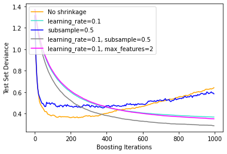

```python
import numpy as np
import matplotlib.pyplot as plt
from sklearn import ensemble
from sklearn import datasets

X, y = datasets.make_hastie_10_2(n_samples=12000,
                                 random_state=1)
# map labels from {-1, 1} to {0, 1}
X               = X.astype(np.float32)
labels, y       = np.unique(y, return_inverse=True)
X_train, X_test = X[:2000], X[2000:]
y_train, y_test = y[:2000], y[2000:]

original_params = {'n_estimators': 1000,
                   'max_leaf_nodes': 4,
                   'max_depth': None,
                   'random_state': 2,
                   'min_samples_split': 5}

plt.figure()

for label, color, setting in [('No shrinkage', 'orange',
                               {'learning_rate': 1.0, 'subsample': 1.0}),
                              ('learning_rate=0.1', 'turquoise',
                               {'learning_rate': 0.1, 'subsample': 1.0}),
                              ('subsample=0.5', 'blue',
                               {'learning_rate': 1.0, 'subsample': 0.5}),
                              ('learning_rate=0.1, subsample=0.5', 'gray',
                               {'learning_rate': 0.1, 'subsample': 0.5}),
                              ('learning_rate=0.1, max_features=2', 'magenta',
                               {'learning_rate': 0.1, 'max_features': 2})]:
    params = dict(original_params)
    params.update(setting)

    clf = ensemble.GradientBoostingClassifier(**params).fit(X_train, y_train)
    test_deviance = np.zeros((params['n_estimators'],),
                             dtype=np.float64)

    for i, y_pred in enumerate(clf.staged_decision_function(X_test)):
        # clf.loss_ assumes that y_test[i] in {0, 1}
        test_deviance[i] = clf.loss_(y_test, y_pred)

    plt.plot((np.arange(test_deviance.shape[0]) + 1)[::5],
             test_deviance[::5],
            '-', color=color, label=label)

plt.legend(loc='upper left')
plt.xlabel('Boosting Iterations')
plt.ylabel('Test Set Deviance')
```

### Histogram-based Gradient Boosting

- Introduced in Scikit-Learn v0.21; **much faster than standard Gradient Boosting** for datasets larger than 10K samples. **Experimental release**: API not 100% compatible with standard Gradient Boosting.
- [classification](https://scikit-learn.org/stable/modules/generated/sklearn.ensemble.HistGradientBoostingClassifier.html#sklearn.ensemble.HistGradientBoostingClassifier) and [regression](https://scikit-learn.org/stable/modules/generated/sklearn.ensemble.HistGradientBoostingRegressor.html#sklearn.ensemble.HistGradientBoostingRegressor) supported.
- Number of bins controlled with `max_bins`. Less bins = more regularization. General rule: use as many bins as possible.
- Loss function regularization is controlled with `l2_regularization`.
- Loss function options:
  - 'least_squares' & 'least_absolute_deviation' - less sensitive to outliers
  - 'poisson' - suited for counts & frequencies
  - 'binary_crossentropy' - for binary classification
  - 'categorical_crossentropy' - for multiclass classification
  - 'auto': default; loss function is chosen depending the the $y$ passed to the fit function.
- Early stopping enabled by default if #samples>10000.
  - Can be controlled by `early-stopping`, `scoring`, `validation_fraction`, `n_iter_no_change` and `tol`.
- Built-in missing value support - no need for standalone imputation.
  - The tree growth algo determine whether a sample with missing data should "go left" or "go right", depending on the *potential gain*.

```python
from sklearn.experimental import enable_hist_gradient_boosting  # noqa
from sklearn.ensemble import HistGradientBoostingClassifier as HGBC
import numpy as np

X = np.array([0, 1, 2, np.nan]).reshape(-1, 1)
y = [0, 0, 1, 1]

gbdt = HGBC(min_samples_leaf=1).fit(X, y); gbdt.predict(X)
```

```
array([0, 0, 1, 1])
```

```python
# explicitly require the feature before using
from sklearn.experimental import enable_hist_gradient_boosting
from sklearn.ensemble import HistGradientBoostingClassifier as HGBC
from sklearn.datasets import make_hastie_10_2

X, y = make_hastie_10_2(random_state=0)
X_train, X_test = X[:2000], X[2000:]
y_train, y_test = y[:2000], y[2000:]

clf = HGBC(max_iter=100).fit(X_train, y_train); clf.score(X_test, y_test)
```

```
0.8965
```

- When the missingness pattern is predictive, the splits can be done on whether the feature value is missing or not:

```python
X = np.array([0, np.nan, 1, 2, np.nan]).reshape(-1, 1)
y = [0, 1, 0, 0, 1]
gbdt = HGBC(min_samples_leaf=1, max_depth=2, learning_rate=1, max_iter=1).fit(X, y)
gbdt.predict(X)
```

```
array([0, 1, 0, 0, 1])
```

- Histogram Gradient Boosting **supports sample weights**.

```python
X = [[1, 0], [1, 0], [1, 0], [0, 1]]
y = [ 0,      0,      1,      0]
w = [ 0,      0,      1,      1] # ignore 1st 2 samples by setting their weight to 0

gb = HGBC(min_samples_leaf=1)
gb.fit(X, y, sample_weight=w)

print(gb.predict([[1, 0]]))
print(gb.predict_proba([[1, 0]])[0, 1])
```

```
[1]
0.9990209190235209
```

- Histogram Gradient Boosting **supports categorical features**.
  - Native category support is often better than one-hot encoding, because one-hot requires more tree depth to achieve equivalent splits.
  - It is also usually better to use native category support, since the *order* of categories should not matter.
  - Done by passing a boolean mask, or a list of integer indices, to `categorical_features` to indicate which are categories:

```python
gbdt = HGBC(categorical_features=[True, False])
gbdt = HGBC(categorical_features=[0])
```

### [Example: Histogram Gradient Boosting - Category Feature Support](https://scikit-learn.org/stable/auto_examples/ensemble/plot_gradient_boosting_categorical.html#sphx-glr-auto-examples-ensemble-plot-gradient-boosting-categorical-py)

- Compares training tmies & prediction performance of a regressor with different encoding strategies:

```python
# load Ames housing dataset
from sklearn.datasets import fetch_openml

X, y = fetch_openml(data_id=41211, as_frame=True, return_X_y=True)

n_categorical_features = (X.dtypes == 'category').sum()
n_numerical_features   = (X.dtypes == 'float').sum()

print(f"#samples: {X.shape[0]}")
print(f"#features: {X.shape[1]}")
print(f"#categorical features: {n_categorical_features}")
print(f"#numerical features: {n_numerical_features}")
```

```
#samples: 2930
#features: 80
#categorical features: 46
#numerical features: 34
```

```python
# create estimator
from sklearn.experimental import enable_hist_gradient_boosting  # noqa
from sklearn.ensemble import HistGradientBoostingRegressor as HGBR
from sklearn.pipeline import make_pipeline
from sklearn.compose import make_column_transformer
from sklearn.compose import make_column_selector

dropper = make_column_transformer(
    ('drop', make_column_selector(dtype_include='category')),
    remainder='passthrough')
hist_dropped = make_pipeline(dropper, HGBR(random_state=42))
```

```python
# one-hot encoding
from sklearn.preprocessing import OneHotEncoder as OHE

one_hot_encoder = make_column_transformer(
    (OHE(sparse=False, handle_unknown='ignore'),
     make_column_selector(dtype_include='category')),
    remainder='passthrough')

hist_one_hot = make_pipeline(one_hot_encoder, HGBR(random_state=42))
```

```python
# ordinal encoding
from sklearn.preprocessing import OrdinalEncoder as OE
import numpy as np

ordinal_encoder = make_column_transformer(
    (OE(handle_unknown='use_encoded_value', unknown_value=np.nan),
     make_column_selector(dtype_include='category')),
    remainder='passthrough')

hist_ordinal = make_pipeline(ordinal_encoder, HGBR(random_state=42))
```

```python
# native category support
categorical_mask = ([True]*n_categorical_features + [False]*n_numerical_features)
hist_native = make_pipeline(
    ordinal_encoder, HGBR(random_state=42, categorical_features=categorical_mask))
```

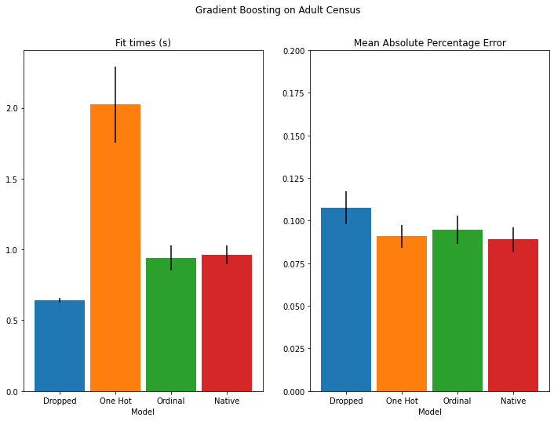

```python
# compare with cross validation
from sklearn.model_selection import cross_validate as CV
import matplotlib.pyplot as plt

scoring = "neg_mean_absolute_percentage_error"
dropped_result = CV(hist_dropped, X, y, cv=3, scoring=scoring)
one_hot_result = CV(hist_one_hot, X, y, cv=3, scoring=scoring)
ordinal_result = CV(hist_ordinal, X, y, cv=3, scoring=scoring)
native_result  = CV(hist_native,  X, y, cv=3, scoring=scoring)

def plot_results(figure_title):
    fig, (ax1, ax2) = plt.subplots(1, 2, figsize=(12, 8))

    plot_info = [('fit_time', 'Fit times (s)', ax1, None),
                 ('test_score', 'Mean Absolute Percentage Error', ax2,
                  (0, 0.20))]

    x, width = np.arange(4), 0.9
    for key, title, ax, y_limit in plot_info:
        items = [dropped_result[key], one_hot_result[key], ordinal_result[key],
                 native_result[key]]
        ax.bar(x, [np.mean(np.abs(item)) for item in items],
               width, yerr=[np.std(item) for item in items],
               color=['C0', 'C1', 'C2', 'C3'])
        ax.set(xlabel='Model', title=title, xticks=x,
               xticklabels=["Dropped", "One Hot", "Ordinal", "Native"],
               ylim=y_limit)
    fig.suptitle(figure_title)

plot_results("Gradient Boosting on Adult Census")
```

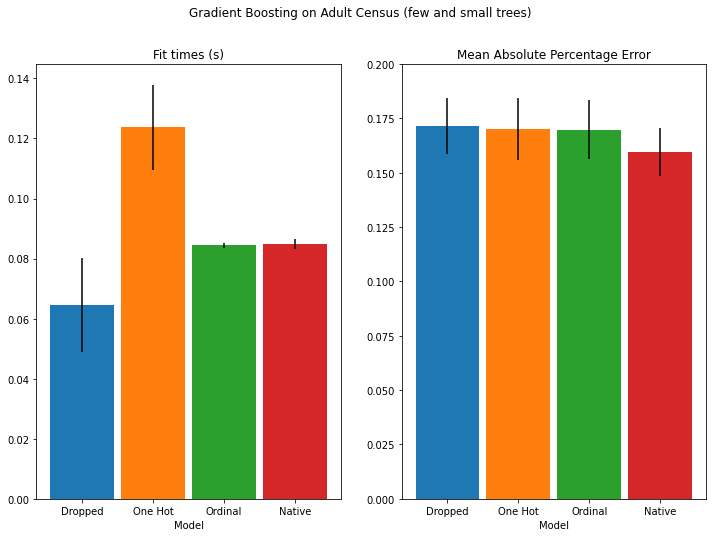

```python
# limiting the #of splits
# rerun analysis with artificially low split count by limiting #trees & tree depth
for pipe in (hist_dropped, hist_one_hot, hist_ordinal, hist_native):
    pipe.set_params(histgradientboostingregressor__max_depth=3,
                    histgradientboostingregressor__max_iter=15)

dropped_result = CV(hist_dropped, X, y, cv=3, scoring=scoring)
one_hot_result = CV(hist_one_hot, X, y, cv=3, scoring=scoring)
ordinal_result = CV(hist_ordinal, X, y, cv=3, scoring=scoring)
native_result = CV(hist_native, X, y, cv=3, scoring=scoring)

plot_results("Gradient Boosting on Adult Census (few and small trees)")
plt.show()
```

### Histrogram Gradient Boosting - Monotonic Constraints

- In some situations, you may already know if a given feature has a positive (or negative) effect on the target value. (For example, credit scores.) Monotonic constraints allow you to add such prior knowledge into the model.
- Definitions (where $F$ is a two-featured predictor):
  - Positive MC:$x_1 \leq x_1' \implies F(x_1, x_2) \leq F(x_1', x_2)$
  - Negative MC:$x_1 \leq x_1' \implies F(x_1, x_2) \geq F(x_1', x_2)$
- `monotonic_cst` controls the constraint. 0 = no constraint; -1 = negative, +1 = positive.
- Used in binary classification problems.

### [Example: Histogram Gradient Boosting w/ Monotonic Constraints](https://scikit-learn.org/stable/auto_examples/ensemble/plot_monotonic_constraints.html#sphx-glr-auto-examples-ensemble-plot-monotonic-constraints-py)

```python
from sklearn.experimental import enable_hist_gradient_boosting  # noqa
from sklearn.ensemble import HistGradientBoostingRegressor as HGBR
from sklearn.inspection import plot_partial_dependence as PPD
import numpy as np
import matplotlib.pyplot as plt
```

```python
rng   = np.random.RandomState(0)
n     = 5000
f_0   = rng.rand(n)  # positive correlation with y
f_1   = rng.rand(n)  # negative correlation with y
X     = np.c_[f_0, f_1]
noise = rng.normal(loc=0.0, scale=0.01, size=n)
y     = (5*f_0 + np.sin(10*np.pi*f_0) -
         5*f_1 - np.cos(10*np.pi*f_1) + noise)
```

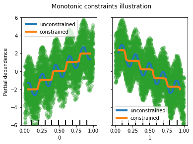

```python
fig, ax = plt.subplots()

# Without any constraint
gbdt = HGBR()
gbdt.fit(X, y)
disp = PPD(gbdt, X, features=[0, 1],
           line_kw={"linewidth": 4, "label": "unconstrained", "color": "tab:blue"},
           ax=ax)

# With positive and negative constraints
gbdt = HGBR(monotonic_cst=[1, -1])
gbdt.fit(X, y)

PPD(gbdt, X, features=[0, 1],
    feature_names=(
        "First feature\nPositive constraint",
        "Second feature\nNegtive constraint",
    ),
    line_kw={"linewidth": 4, "label": "constrained", "color": "tab:orange"},
    ax=disp.axes_)

for f_idx in (0, 1):
    disp.axes_[0, f_idx].plot(
        X[:, f_idx], y, "o", alpha=0.3, zorder=-1, color="tab:green"
    )
    disp.axes_[0, f_idx].set_ylim(-6, 6)

plt.legend()
fig.suptitle("Monotonic constraints illustration")
plt.show()
```

### Histogram Gradient Boosting - Performance

- Gradient Boosting's bottleneck is in building the decision trees. The normal procedure *requires sorting samples at each node* so that potential gain of each split point can be computed efficiently. Splitting a single node has a computational complexity of $\mathcal{O}(n_\text{features} \times n \log(n))$ ($n$ = #samples at the node).

### Stacked Generalization

- A method for combining estimators to reduce bias. Predictions are stacked & fed to a final estimator.
- [classification](https://scikit-learn.org/stable/modules/generated/sklearn.ensemble.StackingClassifier.html#sklearn.ensemble.StackingClassifier) and [regression](https://scikit-learn.org/stable/modules/generated/sklearn.ensemble.StackingRegressor.html#sklearn.ensemble.StackingRegressor) supported.
- `estimators` contains the list of stacked (in parallel) estimators.
- `final_estimator` uses the combined predictions for the final output.

```python
from sklearn.linear_model import RidgeCV, LassoCV
from sklearn.neighbors import KNeighborsRegressor as KNR
estimators = [('ridge', RidgeCV()),
              ('lasso', LassoCV(random_state=42)),
              ('knr',   KNR(n_neighbors=20, metric='euclidean'))]
```

```python
from sklearn.ensemble import GradientBoostingRegressor as GBR
from sklearn.ensemble import StackingRegressor as SR

final_estimator = GBR(n_estimators=25,
                      subsample=0.5,
                      min_samples_leaf=25,
                      max_features=1,
                      random_state=42)

reg = SR(estimators=estimators,
         final_estimator=final_estimator)
```

```python
from sklearn.datasets import load_diabetes
X, y = load_diabetes(return_X_y=True)

from sklearn.model_selection import train_test_split as TTS

X_train, X_test, y_train, y_test = TTS(X, y, random_state=42)
reg.fit(X_train, y_train)
```

```
StackingRegressor(estimators=[('ridge',
                               RidgeCV(alphas=array([ 0.1,  1. , 10. ]))),
                              ('lasso', LassoCV(random_state=42)),
                              ('knr',
                               KNeighborsRegressor(metric='euclidean',
                                                   n_neighbors=20))],
                  final_estimator=GradientBoostingRegressor(max_features=1,
                                                            min_samples_leaf=25,
                                                            n_estimators=25,
                                                            random_state=42,
                                                            subsample=0.5))
```

```python
y_pred = reg.predict(X_test)
from sklearn.metrics import r2_score
print('R2 score: {:.2f}'.format(r2_score(y_test, y_pred)))
```

```
R2 score: 0.53
```

```python
# getting output of stacked estimators:
reg.transform(X_test[:5])
```

```
array([[142.36214074, 138.30765507, 146.1       ],
       [179.70207217, 182.90046333, 151.75      ],
       [139.89924327, 132.47007083, 158.25      ],
       [286.94742491, 292.65164781, 225.4       ],
       [126.88190192, 124.11964797, 164.65      ]])
```

- During classification:
  - when using `stack_method='predict_proba', the first column is dropped if the problem is binary classification.

```python
final_layer_rfr = RFR(n_estimators=10, max_features=1, max_leaf_nodes=5,random_state=42)
final_layer_gbr = GBR(n_estimators=10, max_features=1, max_leaf_nodes=5,random_state=42)

final_layer     = SR(
    estimators=[('rf', final_layer_rfr),
                ('gbrt', final_layer_gbr)],
    final_estimator=RidgeCV()
    )

multi_layer_regressor = SR(
    estimators=[('ridge', RidgeCV()),
                ('lasso', LassoCV(random_state=42)),
                ('knr',   KNR(n_neighbors=20, metric='euclidean'))],
    final_estimator=final_layer
)
multi_layer_regressor.fit(X_train, y_train)

print('R2 score: {:.2f}'.format(multi_layer_regressor.score(X_test, y_test)))
```

```
R2 score: 0.53
```